# TITLE by YOUR_NAME_HERE

## 双变量绘图选择

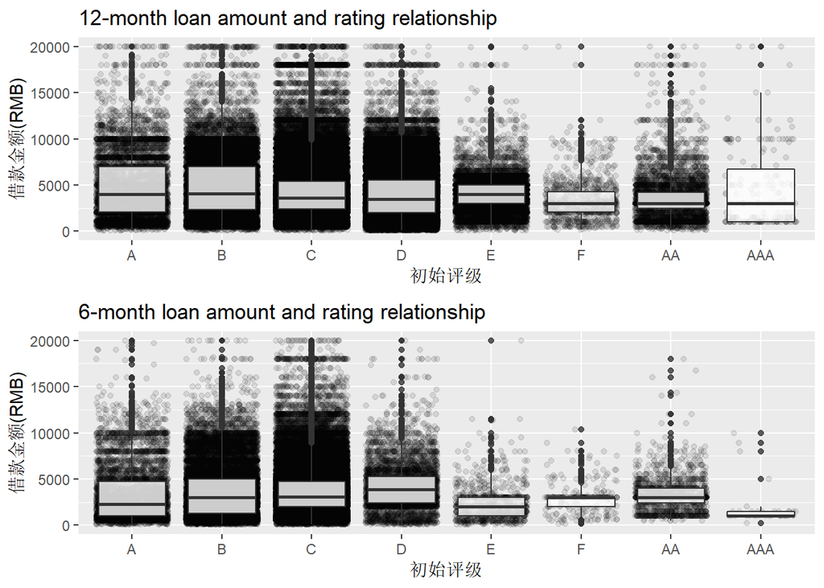

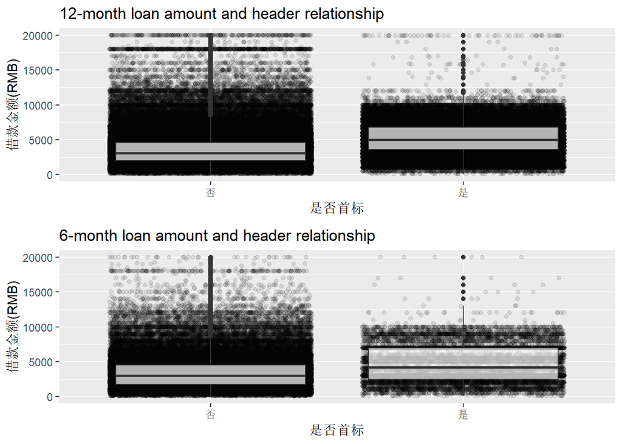

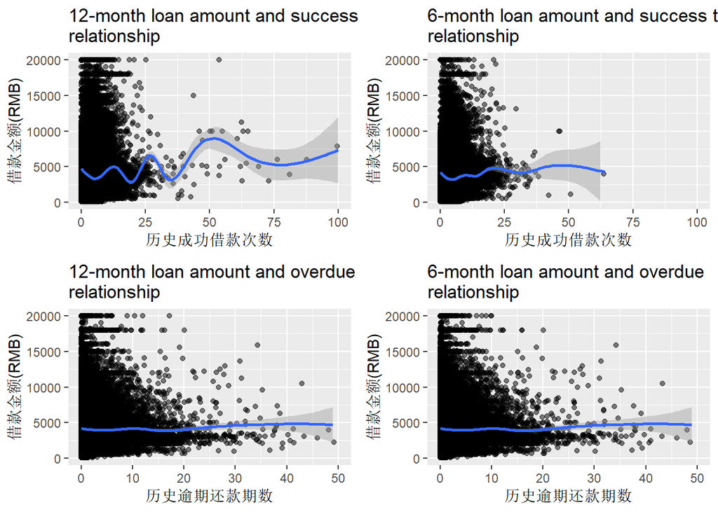

–由图形可以知晓,历史成功借款次数以及历史逾期还款期数对于借款金额的影响并不明显

```
## # A tibble: 40 x 4
##     年龄 money_mean money_median     n
##    <int>      <dbl>        <dbl> <int>
##  1    18      1882.        1500    533
##  2    19      1619.        1114.  2950
##  3    20      1821.        1500   5523
##  4    21      2357.        2000   8524
##  5    22      3250.        3000  14352
##  6    23      3727.        3100  17465
##  7    24      4061.        3500  17856
##  8    25      4270.        3658  17847
##  9    26      4464.        3822  19728
## 10    27      4535.        4000  18995
## # ... with 30 more rows
```

```
## # A tibble: 252,162 x 22
## # Groups:   年龄 [40]
##        X ListingId 借款金额 借款期限 借款利率 初始评级 借款类型 是否首标
##  * <int>     <int>    <int>    <int>    <dbl> <fct>    <fct>    <fct>
##  1     2    126541    18000       12       18 C        其他     否
##  2     4    133291     9453       12       20 D        其他     否
##  3     6    149711    25000       12       18 C        其他     否
##  4     9    162641    20000       12       14 A        普通     否
##  5    11    175451    20000       12       18 B        普通     否
##  6    12    182261    25000       12       16 B        其他     否
##  7    16    193956    14500       12       14 A        其他     否
##  8    17    199461    25000       12       20 E        普通     否
##  9    18    199618    28000       12       16 E        其他     否
## 10    19    209191    20000       12       20 E        普通     否
## # ... with 252,152 more rows, and 14 more variables: 年龄 <int>,
## #   性别 <fct>, 手机认证 <fct>, 户口认证 <fct>, 视频认证 <fct>,
## #   学历认证 <fct>, 征信认证 <fct>, 淘宝认证 <fct>, 认证成功数量 <int>,
## #   历史成功借款次数 <int>, 历史成功借款金额 <dbl>,
## #   历史正常还款期数 <int>, 历史逾期还款期数 <int>, grade <chr>
```

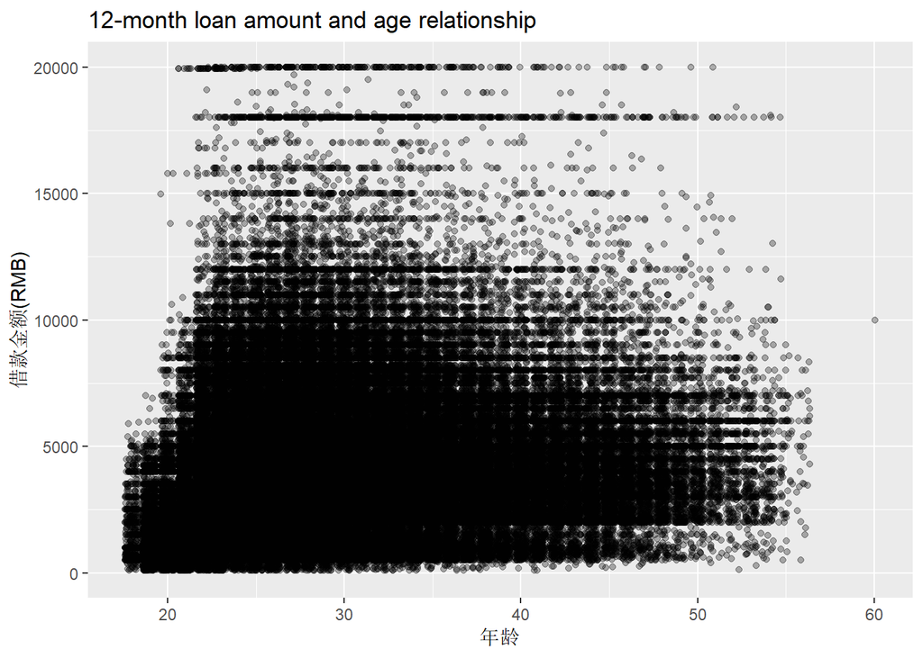

```
## # A tibble: 40 x 4
##     年龄 money_mean money_median     n
##    <int>      <dbl>        <dbl> <int>
##  1    18      1882.        1500    533
##  2    19      1619.        1114.  2950
##  3    20      1821.        1500   5523
##  4    21      2357.        2000   8524
##  5    22      3250.        3000  14352
##  6    23      3727.        3100  17465
##  7    24      4061.        3500  17856
##  8    25      4270.        3658  17847
##  9    26      4464.        3822  19728
## 10    27      4535.        4000  18995
## # ... with 30 more rows
```

```
## # A tibble: 252,162 x 22
## # Groups:   年龄 [40]
##        X ListingId 借款金额 借款期限 借款利率 初始评级 借款类型 是否首标
##  * <int>     <int>    <int>    <int>    <dbl> <fct>    <fct>    <fct>
##  1     2    126541    18000       12       18 C        其他     否
##  2     4    133291     9453       12       20 D        其他     否
##  3     6    149711    25000       12       18 C        其他     否
##  4     9    162641    20000       12       14 A        普通     否
##  5    11    175451    20000       12       18 B        普通     否
##  6    12    182261    25000       12       16 B        其他     否
##  7    16    193956    14500       12       14 A        其他     否
##  8    17    199461    25000       12       20 E        普通     否
##  9    18    199618    28000       12       16 E        其他     否
## 10    19    209191    20000       12       20 E        普通     否
## # ... with 252,152 more rows, and 14 more variables: 年龄 <int>,
## #   性别 <fct>, 手机认证 <fct>, 户口认证 <fct>, 视频认证 <fct>,
## #   学历认证 <fct>, 征信认证 <fct>, 淘宝认证 <fct>, 认证成功数量 <int>,
## #   历史成功借款次数 <int>, 历史成功借款金额 <dbl>,
## #   历史正常还款期数 <int>, 历史逾期还款期数 <int>, grade <chr>
```

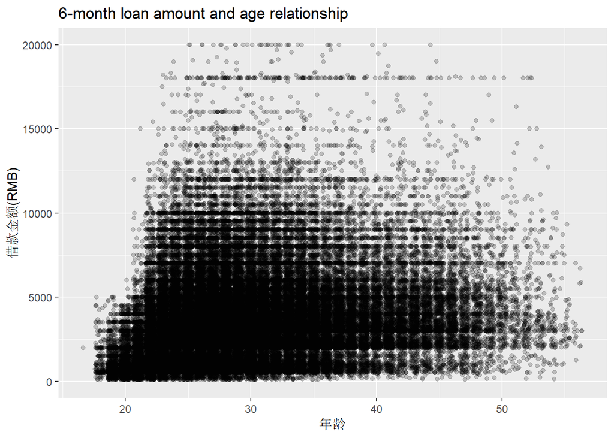

–由上两图可以看出,借款金额和年龄的关系是右偏移的状态,随着年龄的增加,借款金额增加,在25-35岁之间达到最大值,又逐渐下降

```
##
##  Pearson's product-moment correlation
##
## data:  paipaidai_new$借款利率 and paipaidai_new$年龄
## t = 25.795, df = 390140, p-value < 2.2e-16
## alternative hypothesis: true correlation is not equal to 0
## 95 percent confidence interval:
##  0.03812877 0.04439381
## sample estimates:
##        cor
## 0.04126169
```

–由计算结果可以知晓,相关性是0.04,由相关性计算可以看出,相关性并不是非常明显

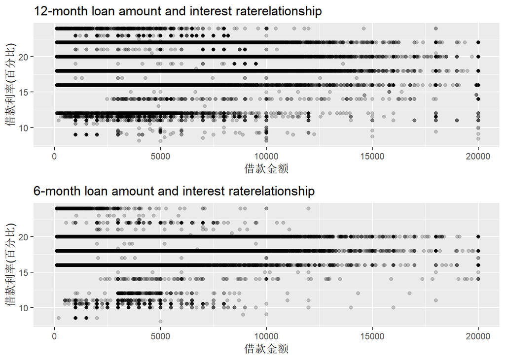

–从上图无法有效的反应出借款金额与借款利率存在反比的关系

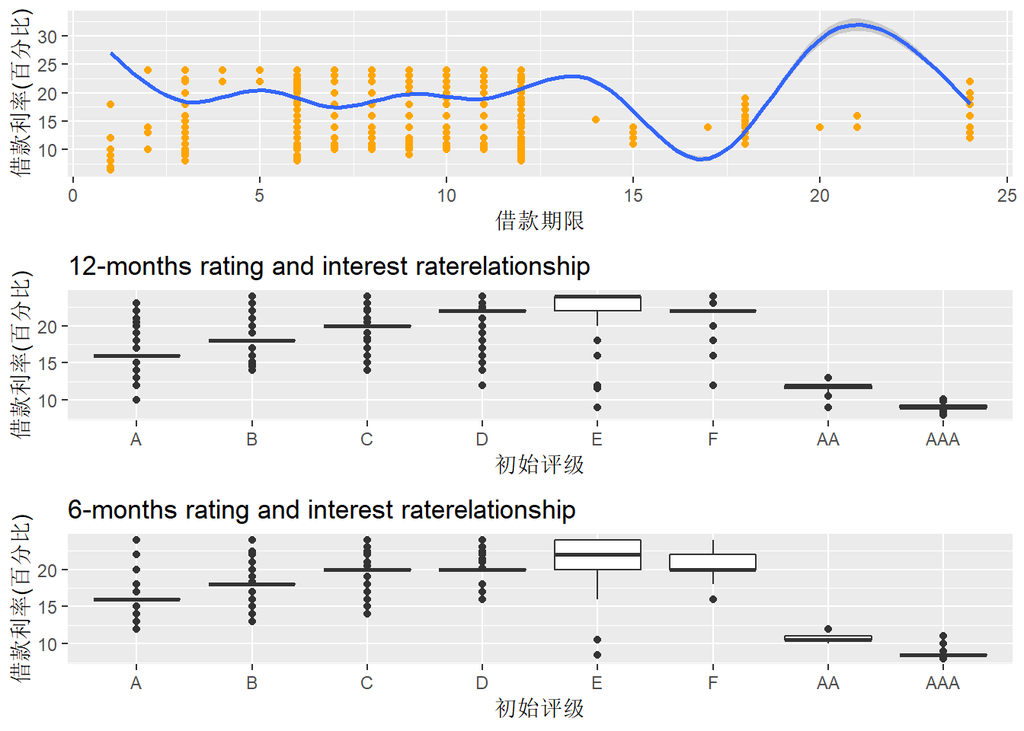

## 双变量分析

#### 探讨你在这部分探究中观察到的一些关系。这些感兴趣的特性与数据集内其他特性有什么区别？

–由以上分析可以知晓,在相同期限内,年龄的大小对于借款金额的多少有一些影响,其他的并没有太明显的影响

#### 你是否观察到主要特性与其他特性之间的有趣关系？

– 从上诉双变量的分析来看,各变量之间的相关性并不是很明显

#### 你发现最强的关系是什么？

– 从上面的图形分析来看,相关性最强的就是借款金额与年龄的分布

# 多变量绘图选择

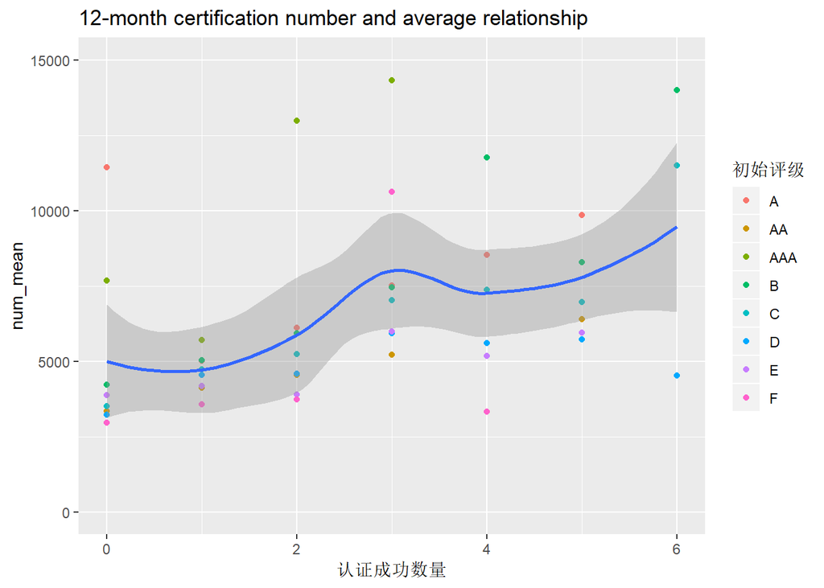

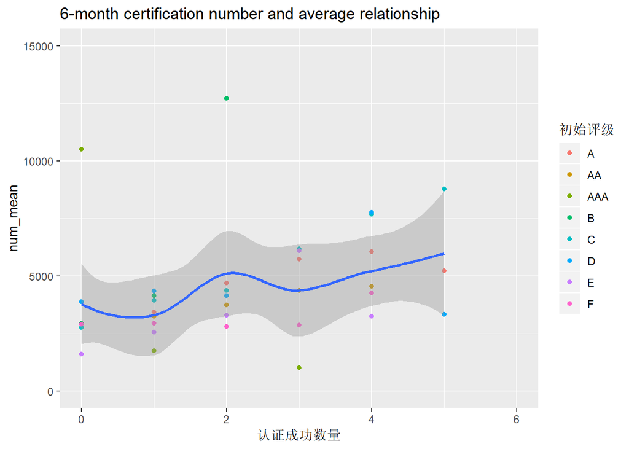

–由上面的两个图形可以看出,不论是借款期为12还是6个月,整体的借款金额平均值都是随着认证成功数量的变大,呈现上升的趋势

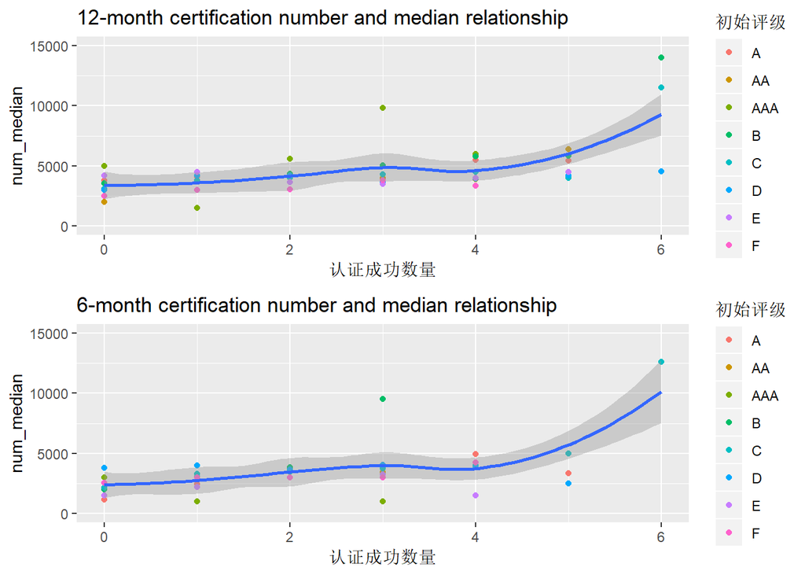

–由中位数的平滑曲线也可以看出,借款金额的中位数随着认证成功数量的增加而增加

## 多变量分析

#### 探讨你在这部分探究中观察到的一些关系。通过观察感兴趣的特性，是否存在相互促进的特性？

–由认证成功的数量的中位数和平均值分布可以看出相互之间存在着正比的关系

#### 这些特性之间是否存在有趣或惊人的联系呢？

–通过上面这些图像的分析,可以看出借款金额的多少与借款人认证成功数量是具有一定的相关性的

#### 选项：你是否创建过数据集的任何模型？讨论你模型的优缺点。

## – 在多变量分析中创建的分析模型,很难体现出认证成功数量和年龄分布之间的关系

## 定稿图与总结

### 绘图一

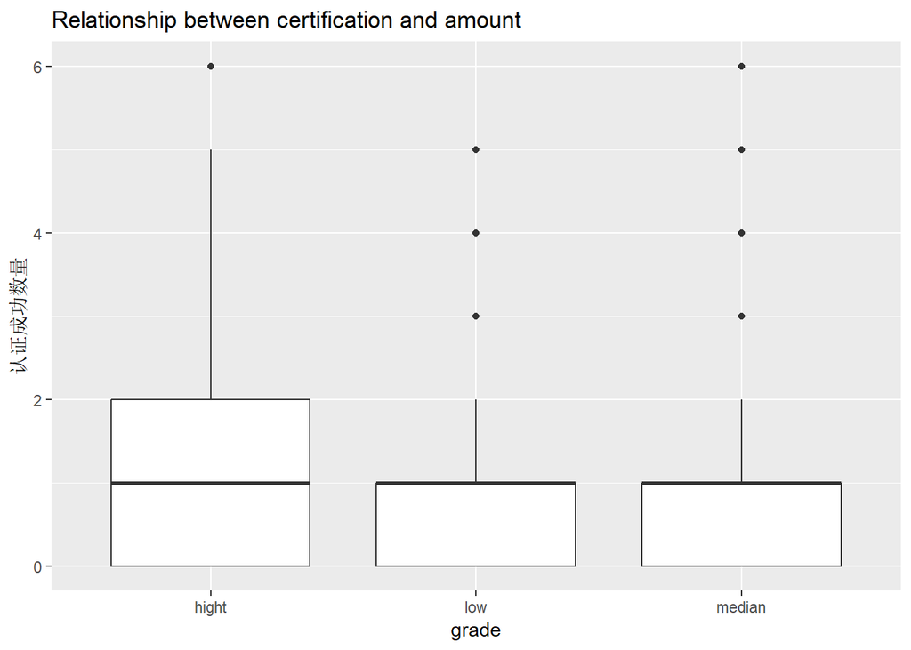

### 描述一

-由箱线图可以看出,借款金额为高等级的在低中阶段的最大值,三分位分布都存在较大的差异

### 绘图二

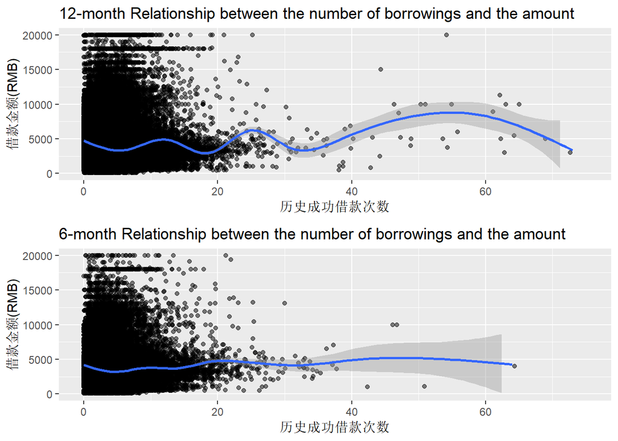

### 描述二

–上图可以看到,借款次数与金额多少的关系并不明显

### 绘图三

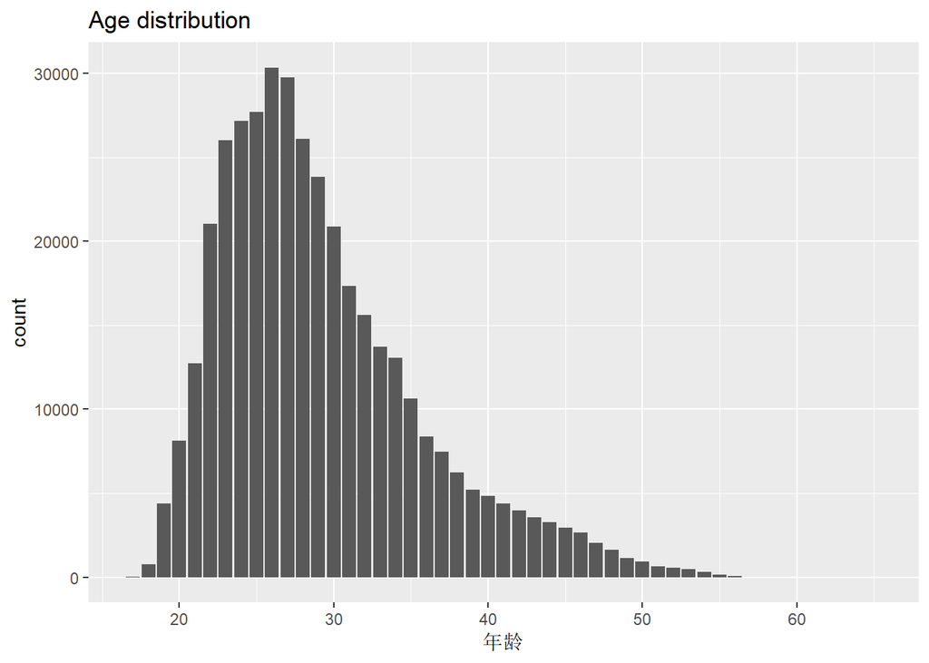

## 反思

–在整个分析的过程中,单变量和双变量分析还可以,能清洗的找出之间的关系,但是在多变量分析时,显得有点单调和不全面 –源数据集由很多的变量,首先需要做一些清洗整理工作,但是我不太会使用R来进行清洗和整理,这是一个短板 –这个的数据分析下来,并没有得出一个非常具有说服力的结论或者结论不是很清晰 –未来工作的方向:本数据集的分析只在LC和LCIS两个数据集,分析的层次比较浅显,在未来可以结合LP的数据集,分析每个ID在各日期的还款状态,还款本金,还款利率,来观察每个ID的还款习惯,还可以将年龄与还款金额,状态,时间结合,看出该ID的日常消费习惯,消费频率等